# XAI-Based Classifiction of High-Risk Neuroblastoma

Data Analysis Report

Author

Mick Dahlhaus

Published

June 22, 2025

> **Disclaimer:** This report is for educational purposes only. The data and findings presented should not be used for clinical decision-making.

# 1 Abstract

Neuroblastoma, a pediatric malignancy marked by clinical heterogeneity, poses significant prognostic challenges, particularly in stratifying high-risk cases. This work investigates whether the clinically assigned high-risk label corresponds to a distinct molecular phenotype by leveraging gene expression data and explainable machine learning. An XGBoost classifier was trained to predict high-risk status from microarray data, achieving robust performance, thereby implicating a predictive molecular signal. Model interpretability via SHAP analysis identified genes such as TERT, FOXP1, and MACF1 as key contributors, aligning with known drivers of tumor progression, immortality, and metastasis. Functional enrichment revealed dysregulated pathways in metabolism, telomerase activity, and transcriptional repression of processes central to high-risk Neuroblastoma. These findings suggest that the high-risk label reflects a reproducible molecular signature, offering potential possebilities for biomarker discovery and stratification.

# 2 Introduction

Neuroblastoma (NB) is the most common extracranial solid tumor in children, accounting for approximately 15% of all pediatric cancer-related deaths. It arises from neural crest cells involved in the development of the sympathetic nervous system. The disease typically affects children under five years of age, with a median age at diagnosis of 17 months.[1] Clinically, NB is highly heterogeneous, presenting with a wide spectrum of symptoms that depend on the tumor’s location, size, and extent of metastasis. These may include systemic manifestations such as fever, weight loss and fatigue, as well as localized signs like abdominal mass, bone pain, or neurological deficits.

The High-risk label in NB is a clinically defined classification used for prognostic stratification and treatment planning. However, this label is derived from a combination of clinical parameters rather than direct molecular evidence. As such, it remains unclear whether high-risk status corresponds to a distinct biological phenotype or simply reflects composite clinical features.

# 3 Hypothesis and Aim

The aim is to develop a ML model capable of accurately predicting the high-risk label in NB based on gene expression data. This two-step approach first focuses on prediction: if the model achieves strong performance, it likely implies that the input features contain molecular signals associated with the clinical label.

The second step involves interpreting the trained model to identify which genes most strongly influence its classification decisions. This interpretability component falls under the broader framework of explainable artificial intelligence (XAI), which seeks to make ML models transparent and their decision-making processes understandable to humans.

The goal is to use this framework to uncover potential biological underpinnings of the high-risk label, to determine whether this clinically derived category reflects a consistent molecular signature that could inform future biomarker discovery or therapeutic targeting.

# 4 Approach and Methods

## 4.1 Prediction Plan

To predict the high risk label in NB, a supervised machine learning approach using XGBoost is employed. XGBoost is a gradient boosting framework based on decision trees and is well-suited for structured, high-dimensional data such as the microarray gene expression at hand. It is robust to multicollinearity, accommodates missing values natively, and requires minimal preprocessing.[4] Beyond prediction, the model enables straight forward interpretation of gene-level contributions, allowing users to identify features potentially underlying clinically defined outcomes.

## 4.2 Preprocessing

To ensure consistency between datasets, first the microarray sample identifiers are cleande up and only those with matching clinical data are retained, as missing labels were structurally absent and could not be imputed. The microarray data lacked gene annotations, so the original annotation file was retrieved for the “Agilent-020382 Human Custom Microarray 44k” [2][3] platform to map probe identifiers and gene symbols. Control probes were removed based on this metadata, as they carry no relevant biological signal for our analysis. Also MYCN probes were excluded to prevent data leakage, since the MYCN status is part of the clinical definition of the high-risk label and would otherwise give the model unfair prior knowledge of the label.

To further prepare the dataset for analytical and predictive usage a pre-processing pipeline was employed (described in Flowchart 1).

[figure not shown]

Flowchart 1 – Pre-processing pipeline

```python
log2_transformer = FunctionTransformer(func=lambda x: np.log2(x + 1), validate=False)

# Pipeline definition
microarray_pipeline = Pipeline([
    ('log2_transform', log2_transformer),
    ('quantile_norm', QuantileTransformer(output_distribution='normal', random_state=0)),
    ('impute', SimpleImputer(strategy='median')),
    ('filter_low_variance', VarianceThreshold(threshold=0.01)),
])

# Split data again for transformation
X = merged_exp_df.iloc[:, 27:]

processed_microarray_df = microarray_pipeline.fit_transform(X)

#rebuild the original dataframe
kept_genes = X.columns[microarray_pipeline.named_steps['filter_low_variance'].get_support()]
processed_microarray_df = pd.DataFrame(processed_microarray_df, index=X.index, columns=kept_genes)
final_df = pd.concat([merged_exp_df.iloc[:, :27], processed_microarray_df], axis=1)

# Final sanity checks
final_df = final_df.reset_index(drop=True)

for col in final_df.select_dtypes(include=['object', 'category']).columns:
    final_df[col] = final_df[col].astype(str)

assert processed_microarray_df.columns.equals(kept_genes)
```

## 4.3 High Risk Classification

To identify the optimal model for high-risk classification, a two-stage XGBoost pipeline was implemented. In the first stage, a 5-fold cross-validated grid search over learning rate (eta) and tree depth was conducted, with mean AUC used for evaluation and ROC curves generated for comparison. To address class imbalance, the scale_pos_weight parameter was applied, calculated as the ratio of negative to positive samples. In the second stage, the best hyperparameter combination was used to train a final model on the full training set (Table 1). Its performance was then assessed on a held-out test set using AUC, F1 score, accuracy, and specificity (Table 2).

```r
#  Setup
# --------------------------------------------------------------
reuse_models      <- TRUE            # TRUE -> try to load, not train
final_model_path  <- "final_model_HR.rds"

#  Compute scale_pos_weight to handle unbalanced classes
# --------------------------------------------------------------
scale_pos_weight <- sum(y_train == 0) / sum(y_train == 1)


if (reuse_models && file.exists(final_model_path)) {

  message("Loading pretrained model from: ", final_model_path)
  final_model <- readRDS(final_model_path)

  if (file.exists("cv_artifacts.rds")) {
    cv_art <- readRDS("cv_artifacts.rds")
    roc_cv_all <- cv_art$roc_cv_all
    results    <- cv_art$results
    best_params <- results %>% slice_max(AUC_CV, n = 1)   # <- needed later
  } else {
    stop("cv_artifacts.rds not found: cannot plot CV ROC curves. "
         , "Run once with reuse_models <- FALSE to generate it.")
}

} else {

  message("Running CV + training …")

  # ---------- 1. Hyper-parameter grid ---------------------------------------
  param_grid <- expand.grid(
    eta        = c(0.01, 0.1),
    max_depth  = c(3, 5),
    nrounds    = c(100),
    colsample_bytree = c(0.8),
    KEEP.OUT.ATTRS = FALSE
  )

  roc_cv_all <- vector("list", nrow(param_grid))
  results    <- tibble()

  # ---------- 2. 5-fold CV loop ---------------------------------------------
  for (i in seq_len(nrow(param_grid))) {
    p <- param_grid[i, ]

    cv <- xgb.cv(
      data              = X_train,
      label             = y_train,
      nfold             = 5,
      eta               = p$eta,
      max_depth         = p$max_depth,
      nrounds           = p$nrounds,
      objective         = "binary:logistic",
      eval_metric       = "auc",
      early_stopping_rounds = 10,
      prediction        = TRUE,
      scale_pos_weight  = scale_pos_weight,
      nthread           = parallel::detectCores())

    roc_obj <- pROC::roc(y_train, cv$pred, quiet = TRUE)

    roc_cv_all[[i]] <- tibble(
      FPR       = 1 - roc_obj$specificities,
      TPR       = roc_obj$sensitivities,
      eta       = p$eta,
      max_depth = p$max_depth,
      nrounds   = p$nrounds,
      AUC       = as.numeric(pROC::auc(roc_obj)))

    results <- bind_rows(results,
      tibble(eta = p$eta,
             max_depth = p$max_depth,
             nrounds   = p$nrounds,
             AUC_CV    = max(cv$evaluation_log$test_auc_mean)))

    saveRDS(
      list(
        roc_cv_all = roc_cv_all,   # all ROC curves from the 5-fold CV
        results    = results       # the CV AUC summary table
      ),
      file = "cv_artifacts.rds"
    )
  }

  # ---------- 3. Train final model on full train set ------------------------
  best_params <- results %>% slice_max(AUC_CV, n = 1)

  final_model <- xgboost(
    data              = X_train,
    label             = y_train,
    eta               = best_params$eta,
    max_depth         = best_params$max_depth,
    nrounds           = best_params$nrounds,
    objective         = "binary:logistic",
    eval_metric       = "auc",
    scale_pos_weight  = scale_pos_weight,
    nthread           = parallel::detectCores())

  saveRDS(final_model, final_model_path)
}
```

```
Loading pretrained model from: final_model_HR.rds
```

```r
#  Hold-out test evaluation
# --------------------------------------------------------------
prob_test <- predict(final_model, X_test)
pred_test <- ifelse(prob_test > 0.5, 1, 0)

roc_final <- pROC::roc(y_test, prob_test, quiet = TRUE)
auc_final <- pROC::auc(roc_final)

cm <- caret::confusionMatrix(
  factor(pred_test, levels = c(0, 1)),
  factor(y_test,  levels = c(0, 1)))
```

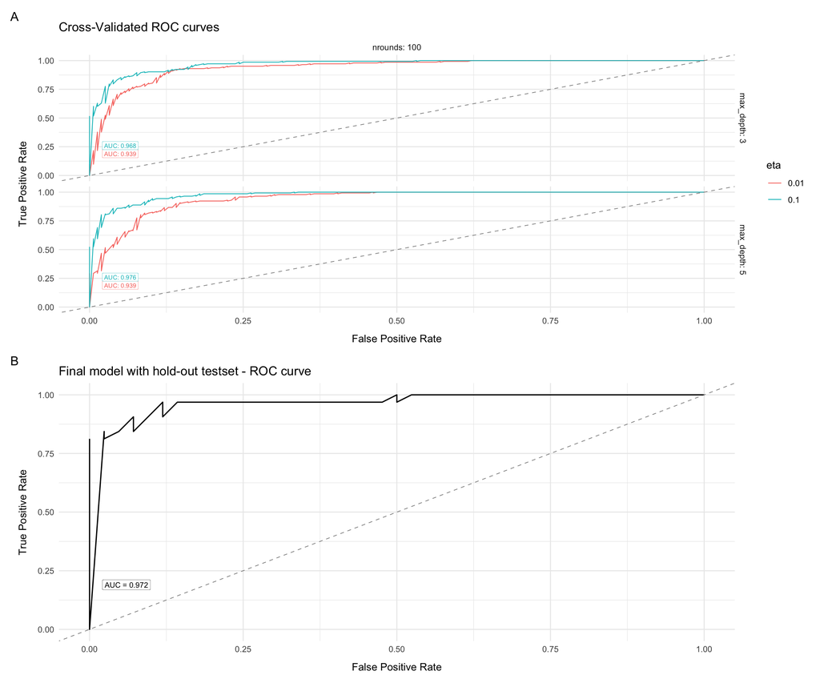

A: ROC curves from 5-fold cross-validation, comparing XGBoost models across different hyperparameter settings. AUC values are shown for each configuration, illustrating model performance during hyperparameter tuning. B: ROC curve of the final model evaluated on the independent hold-out test set, achieving an AUC of 0.972, indicating strong discriminatory performance.

Probes without gene annotations may target non-coding RNAs, splice junctions, or novel loci, which can hold valuable predictive signals. But in this case, where the goal is to uncover biological insight underlying clinical labels, excluding unannotated probes is justified, as they hinder gene-level interpretation and downstream functional analysis.

Final Hyperparameters

| Parameter | Value |
| --- | --- |
| Learning Rate (eta) | 0.1 |
| Max Depth | 5 |
| Rounds | 100 |
| Objective | binary:logistic |
| Evaluation Metric | auc |
| Class Imbalance Weight | 1.09 |
| Column Subsample (bytree) | 0.8 |

Final Model Performance

| Metric | Value |
| --- | --- |
| Accuracy | 0.905 |
| Kappa | 0.807 |
| Sensitivity | 0.929 |
| Specificity | 0.875 |
| PPV | 0.907 |
| NPV | 0.903 |
| F1 | 0.918 |
| AUC | 0.972 |

# 5 Results

Following model training, feature importance was assessed and interpreted in the context of established biological knowledge from literature and scientific studies.

To assess feature importance in the model, SHAP (SHapley Additive exPlanations) values were extracted directly from the trained XGBoost classifier using exact (non-approximated) prediction contributions. This resulted in a matrix of SHAP values for each feature across all training samples. Feature importance was then summarized by computing the mean absolute SHAP value for each feature, providing a global measure of its contribution to model predictions (Figure 2).

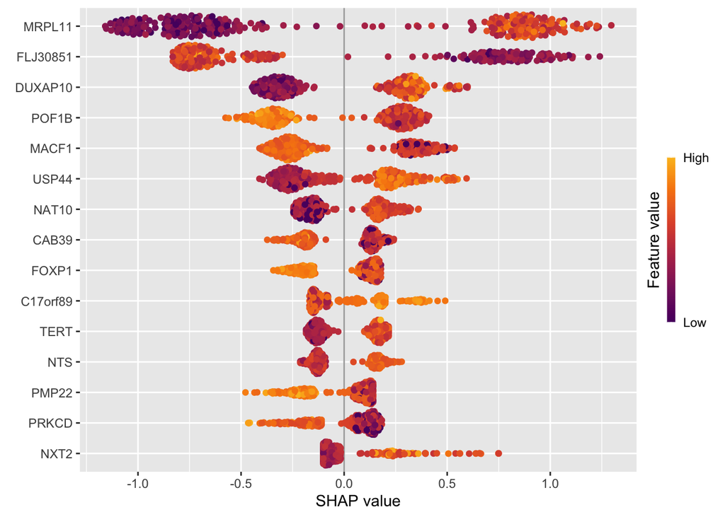

The ranked genes from the SHAP-based feature importance analysis of the model were then used as a single ordered list for functional enrichment analysis via “GOrilla”.

These genes revealed strong associations with metabolic processes, including carboxylic acid and lipid metabolism, and solute transport (Table 3).

Enriched GO Terms Relevant to Neuroblastoma

| Term ID | FDR | Biological Domain | Relevance to NB |
| --- | --- | --- | --- |
| GO:0019752 | 6.62e-33 | Central metabolism | Tumor cells rely on metabolic reprogramming [6] |
| GO:0006631 | 1.96e-30 | Lipid metabolism | FAO supports high-risk NB survival [7] |
| GO:1902600 | 3.55e-24 | pH regulation, homeostasis | pH control linked to drug resistance and metastasis [8] |
| GO:0006869 | 1.71e-23 | Lipid trafficking | Altered lipid flux affects proliferation [9] |
| GO:0008152 | 7.05e-23 | Broad cellular metabolism | Supports rapid tumor growth and survival [6] |

The results from “GOrilla” yielded several redundant and obsolet GO terms. Semantic simplification via similarity clustering (Figure 3) and filtering by “REVIGO” reudced these into coherent biological themes (Table 4).

[figure not shown]

REVIGO Semantic Clustering

Enriched GO Terms Clustered by REVIGO

| Term ID | Dispensability | Clustered Domain | Relevance to NB |
| --- | --- | --- | --- |
| GO:0019752 | 0.000 | Organic acid metabolism | Influences neuroblastoma cell growth and survival [10] |
| GO:0044281 | 0.170 | General metabolism | Molecule metabolism reprogrammed in MYCN+ NB [11] |
| GO:1902600 | 0.008 | Ion transport / pH regulation | Targeting V-ATPase reverses resistance [12] |
| GO:0034440 | 0.180 | Lipid catabolism | Essential for NB growth in hypoxia [7] |
| GO:0051056 | 0.020 | Cell signaling and control | Affects Rho signaling, invasion in NB [8] |

Further, “g:Profiler” pathway analysis linked the gene set to specific signaling modules such as telomerase activity, insulin receptor signaling, and cell junction organization (Figure 4).

[figure not shown]

g:Profiler pathway analysis results

These results highlight how key genes such as TERT, FOXP1, and MACF1 connect our model features to core biological processes implicated in the high-risk label, including cellular immortalization, proliferation, and metastasis (Table 5).

g:Profiler selected Functional and Regulatory Features

| Category | Enriched Term or Feature | Involved Genes | Relevance to NB |
| --- | --- | --- | --- |
| GO:MF | Insulin receptor substrate binding | PRKCD, AKAP7 | IGF pathway supports NB cell survival and therapy resistance [13] |
| GO:CC | Telomerase holoenzyme complex | TERT | TERT rearrangement defines ultra-high-risk NB subtype [14] |
| GO:CC | Cell junction | MACF1 | Fusion defects promote migration in NB [15] |
| TF motif | Gfi1 binding site | FOXP1 | Inhibits cell growth and attenuates tumorigenicity of NB [16] |
| miRNA | miR-512-5p target | Unknown | miRNAs modulate MYCN and NB therapy response [17] |
| HPO | Mediastinal lymphadenopathy | Clinical phenotype | Thoracic NB often presents with mediastinal involvement [18] |

These converging lines of evidence confirm that the model captures biologically meaningful features, offering mechanistic insight into the determinants of the high-risk label, potentially guiding therapeutic stratification and revealing that the clinical derived high-risk label has evident molecular underpinnings.

# 6 Discussion

XAI is used increasingly more to analyze omics data and gain insights into the underlying biological processes.[19] While the derived genes from SHAP importance analysis (Figure 2) are in line with literature and scientific articles, it is important to understand that SHAP analysis does not quantify the importance of predictors in the real‐world problem, but rather their importance to the model’s predictions.

SHAP explains how the model uses features, not why they are biologically relevant. Importance can also reflect data structures exploited by the model, rather than true mechanistic relationships. Moreover, different model architectures (e.g., tree-based vs. linear) can yield divergent SHAP interpretations, further complicating biological conclusions.[20]

In addition, genes often co-express due to shared regulatory mechanisms. In such cases, SHAP values may arbitrarily assign importance to one gene among a group of correlated features, which can mislead downstream biological interpretations. SHAP values also do not imply causality, as observed associations may be indirect or confounded by technical artifacts or downstream effects (e.g. batch effects or phenotype-driven signals).

Finally, because model training is typically guided by phenotypic labels, genes with low SHAP importance may still be functionally critical if they contribute through synergistic or non-linear interactions—relationships that SHAP may not adequately capture.[20]

To address these limitations, one next step is to compare clustering results based on SHAP values with those derived from raw microarray expression data. This may help uncover latent biological structures or non-linear associations that conventional expression-based clustering overlooks. Furthermore, evaluating the consistency of SHAP-derived gene rankings across different model types and data partitions can provide insight into the robustness of feature importance scores. Together, these steps may improve the interpretability and biological relevance of XAI outputs in the context of NB.

# 7 References

[1] Mahapatra S, Challagundla KB. Neuroblastoma. [Updated 2023 Jul 10]. In: StatPearls [Internet]. Treasure Island (FL): StatPearls Publishing; 2025 Jan-. Available from: https://www.ncbi.nlm.nih.gov/books/NBK448111/

[2] Zhang W, Yu Y, Hertwig F, et al. Comparison of RNA-seq and microarray-based models for clinical endpoint prediction. Genome Biol. 2015;16:133. doi:10.1186/s13059-015-0694-1.

[3] GEO Accession viewer. GPL16876 [Internet]. Available from: https://www.ncbi.nlm.nih.gov/geo/query/acc.cgi?acc=GPL16876

[4] XGBoost Documentation [Internet]. Available from: https://xgboost.readthedocs.io/en/stable/index.html

[5] Supek F, Bošnjak M, Škunca N, Šmuc T. REVIGO summarizes and visualizes long lists of Gene Ontology terms. PLoS ONE. 2011;6(7):e21800. doi:10.1371/journal.pone.0021800.

[6] Hanahan D. Hallmarks of Cancer: New Dimensions. Cancer Discov. 2022 Jan;12(1):31-46. doi:10.1158/2159-8290.CD-21-1059.

[7] Du B, Zhang F, Zhou Q, et al. Joint analysis of the metabolomics and transcriptomics uncovers the dysregulated network and develops the diagnostic model of high-risk neuroblastoma. Sci Rep. 2023;13:16991. doi:10.1038/s41598-023-43988-w.

[8] Raghunand N, Gillies RJ. pH and drug resistance in tumors. Drug Resist Updat. 2000 Jan;3(1):39-47. doi:10.1054/drup.2000.0119.

[9] Eling TE, Glasgow WC. Cellular proliferation and lipid metabolism: importance of lipoxygenases in modulating epidermal growth factor-dependent mitogenesis. Cancer Metast Rev. 1994;13(4):397-410. doi:10.1007/BF00666106.

[10] Sakowicz-Burkiewicz M, Pawełczyk T, Zyśk M. Role of Energy Metabolism in the Progression of Neuroblastoma. Int J Mol Sci. 2021;22(21):11421. doi:10.3390/ijms222111421.

[11] Bansal M, Gupta A, Ding H-F. MYCN and Metabolic Reprogramming in Neuroblastoma. Cancers (Basel). 2022;14(17):4113. doi:10.3390/cancers14174113.

[12] Bhoopathi P, Pradhan AK, Bacolod MD, et al. Regulation of neuroblastoma migration, invasion, and in vivo metastasis by genetic and pharmacological manipulation of MDA-9/Syntenin. Oncogene. 2019;38(41):6781-6793. doi:10.1038/s41388-019-0920-5.

[13] Megison ML, Gillory LA, Beierle EA. Cell Survival Signaling in Neuroblastoma. Anti-Cancer Agents Med Chem. 2013 May;13(4):563-75. doi:10.2174/1871520611313040005.

[14] Valentijn LJ, Koster J, Zwijnenburg DA, et al. TERT rearrangements are frequent in neuroblastoma and identify aggressive tumors. Nat Genet. 2015 Dec;47(12):1411-1414. doi:10.1038/ng.3438.

[15] Schleiermacher G, Bourdeaut F, Combaret V, et al. Stepwise occurrence of a complex unbalanced translocation in neuroblastoma leading to insertion of a telomere sequence and late chromosome 17q gain. Oncogene. 2005 Apr 21;24(16):3377-84. doi:10.1038/sj.onc.1208486.

[16] Ackermann S, Kocak H, Hero B, et al. FOXP1 inhibits cell growth and attenuates tumorigenicity of neuroblastoma. BMC Cancer. 2014 Oct 4;14:840. doi:10.1186/1471-2407-14-840.

[17] Gholamin S, Mirzaei H, Razavi SM, et al. GD2-targeted immunotherapy and potential value of circulating microRNAs in neuroblastoma. J Cell Physiol. 2018 Feb;233(1):866-879. doi:10.1002/jcp.25793.

[18] Choi JH, Ro JY. Mediastinal neuroblastoma, ganglioneuroblastoma, and ganglioneuroma: Pathology review and diagnostic approach. Semin Diagn Pathol. 2022 May;39(2):120-130. doi:10.1053/j.semdp.2021.06.007.

[19] Toussaint PA, Leiser F, Thiebes S, Schlesner M, Brors B, Sunyaev A. Explainable artificial intelligence for omics data: a systematic mapping study. Brief Bioinform. 2023 Nov 22;25(1):bbad453. doi: 10.1093/bib/bbad453. PMID: 38113073; PMCID: PMC10729786.

[20] Ponce-Bobadilla AV, Schmitt V, Maier CS, Mensing S, Stodtmann S. Practical guide to SHAP analysis: Explaining supervised machine learning model predictions in drug development. Clin Transl Sci. 2024 Nov;17(11):e70056. doi: 10.1111/cts.70056. PMID: 39463176; PMCID: PMC11513550.